# Task3 邻接矩阵

李梦

2021/3/14

# **一、由College Football所构建的网络生成邻接矩阵，并解读**

## 1、准备工作

```r
#清除工作环境
cat("/014")
```

```
## /014
```

```r
rm(list=ls())
```

```r
library(igraph)#加载相应的安装包
data_football=read.csv("C:/Users/admini/Desktop/football.csv",header = T)#导入football数据集
set.seed(50)#生成随机种子，使每次绘制的图相同
```

## 2、根据数据集构建football网络结构，并绘制出网络结构图

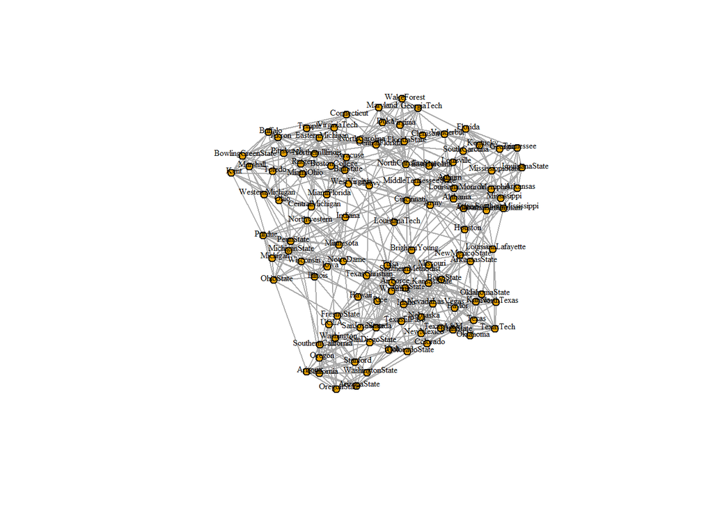

```r
g_football=graph_from_data_frame(data_football,directed = F)
plot(g_football,vertex.label.cex=0.5,#设置节点标签字号
     vertex.size=5,#设置节点大小
     vertex.label.dist=0.4,#设置节点的标签位置
     vertex.label.color="black",#修改节点标签的颜色
     )
```

## 3、根据football网络结构数据图得到邻接矩阵

```r
adj_football=as_adjacency_matrix(g_football,
                                 type="both",#得到一个对称矩阵
                                 sparse =FALSE#创建非稀疏矩阵
                                 )
print(adj_football)
```

```
##                      BrighamYoung FloridaState Iowa KansasState NewMexico
## BrighamYoung                    0            1    0           0         1
## FloridaState                    1            0    0           0         0
## Iowa                            0            0    0           1         0
## KansasState                     0            0    1           0         0
## NewMexico                       1            0    0           0         0
## TexasTech                       0            0    0           1         1
## PennState                       0            0    1           0         0
## SouthernCalifornia              0            0    0           0         0
## ArizonaState                    0            0    0           0         0
## SanDiegoState                   1            0    0           0         1
## Baylor                          0            0    0           0         0
## NorthTexas                      0            0    0           1         0
## NorthernIllinois                0            0    0           0         0
## Northwestern                    0            0    1           0         0
## WesternMichigan                 0            0    1           0         0
## Wisconsin                       0            0    1           0         0
## Wyoming                         1            0    0           0         1
## Auburn                          0            0    0           0         0
## Akron                           0            0    0           0         0
## VirginiaTech                    0            0    0           0         0
## Alabama                         0            0    0           0         0
## UCLA                            0            0    0           0         0
## Arizona                         0            0    0           0         0
## Utah                            1            0    0           0         1
## ArkansasState                   0            0    0           0         0
## NorthCarolinaState              0            1    0           0         0
## BallState                       0            0    0           1         0
## Florida                         0            1    0           0         0
## BoiseState                      0            0    0           0         1
## BostonCollege                   0            0    0           0         0
## WestVirginia                    0            0    0           0         0
## BowlingGreenState               0            0    0           0         0
## Michigan                        0            0    0           0         0
## Virginia                        1            1    0           0         0
## Buffalo                         0            0    0           0         0
## Syracuse                        1            0    0           0         0
## CentralFlorida                  0            0    0           0         0
## GeorgiaTech                     0            1    0           0         0
## CentralMichigan                 0            0    0           0         0
```

[output cut: 2729 more lines]

```
## Missouri                             0
## Clemson                              0
## NevadaLasVegas                       0
## WakeForest                           0
## OregonState                          0
## TexasChristian                       0
## UtahState                            0
## MiamiFlorida                         0
## Maryland                             0
## Indiana                              0
## OklahomaState                        0
## California                           0
## Hawaii                               0
## Arkansas                             0
## AlabamaBirmingham                    0
```

## 4、对得到的邻接矩阵进行矩阵分析

### （1）统计每个球队进行了多少场比赛

```r
dim(adj_football)#计算矩阵的行数和列数
```

```
## [1] 115 115
```

```r
edge_union=colSums(adj_football)#计算每个节点（足球队）有多少条边（进行了多少场比赛）
edge_union#显示每个节点连接边数的汇总矩阵
```

```
##         BrighamYoung         FloridaState                 Iowa
##                   12                   12                   12
##          KansasState            NewMexico            TexasTech
##                   12                   11                   12
##            PennState   SouthernCalifornia         ArizonaState
##                   12                   12                   11
##        SanDiegoState               Baylor           NorthTexas
##                   11                   10                   10
##     NorthernIllinois         Northwestern      WesternMichigan
##                   10                   11                   10
##            Wisconsin              Wyoming               Auburn
##                   12                   11                   11
##                Akron         VirginiaTech              Alabama
##                   11                   11                   11
##                 UCLA              Arizona                 Utah
##                   11                   11                   11
##        ArkansasState   NorthCarolinaState            BallState
##                   10                   11                   10
##              Florida           BoiseState        BostonCollege
##                   11                    9                   11
##         WestVirginia    BowlingGreenState             Michigan
##                   11                   11                   11
##             Virginia              Buffalo             Syracuse
##                   10                   11                   11
##       CentralFlorida          GeorgiaTech      CentralMichigan
##                    8                   11                   11
##               Purdue             Colorado        ColoradoState
##                   11                   11                   10
##          Connecticut      EasternMichigan         EastCarolina
##                    7                   11                   11
##                 Duke          FresnoState            OhioState
##                   11                   11                   11
##              Houston                 Rice                Idaho
##                   11                   11                    9
##           Washington               Kansas    SouthernMethodist
##                   11                   10                   12
##                 Kent           Pittsburgh             Kentucky
##                   10                   11                   10
##           Louisville        LouisianaTech      LouisianaMonroe
##                   10                   10                    8
```

[output cut: 23 more lines]

```
##                   10                   10                   10
##   LouisianaLafayette                Texas             Marshall
##                    8                   11                   10
##        MichiganState             Missouri              Clemson
##                   11                   10                   10
##       NevadaLasVegas           WakeForest          OregonState
##                   12                   10                   10
##       TexasChristian            UtahState         MiamiFlorida
##                   11                    9                   10
##             Maryland              Indiana        OklahomaState
##                   11                   11                   10
##           California               Hawaii             Arkansas
##                   11                   11                   10
##    AlabamaBirmingham
##                   10
```

```r
mean_football=sum(edge_union)/dim(adj_football)[1]
print(mean_football)
```

```
## [1] 10.66087
```

```r
which(edge_union<mean_football)#统计有多少人物的被提及次数小于平均值
```

```
##               Baylor           NorthTexas     NorthernIllinois
##                   11                   12                   13
##      WesternMichigan        ArkansasState            BallState
##                   15                   25                   27
##           BoiseState             Virginia       CentralFlorida
##                   29                   34                   37
##        ColoradoState          Connecticut                Idaho
##                   42                   43                   51
##               Kansas                 Kent             Kentucky
##                   53                   55                   57
##           Louisville        LouisianaTech      LouisianaMonroe
##                   58                   59                   60
## MiddleTennesseeState                 Ohio  SouthernMississippi
##                   64                   72                   76
##               Toledo             AirForce              Rutgers
##                   86                   93                   94
##              Georgia       LouisianaState   LouisianaLafayette
##                   95                   96                   97
##             Marshall             Missouri              Clemson
##                   99                  101                  102
##           WakeForest          OregonState            UtahState
##                  104                  105                  107
##         MiamiFlorida        OklahomaState             Arkansas
##                  108                  111                  114
##    AlabamaBirmingham
##                  115
```

```r
max(edge_union)#计算一个节点最多连接的边数
```

```
## [1] 12
```

```r
which(edge_union==max(edge_union))#找出边数连接最多的节点
```

```
##       BrighamYoung       FloridaState               Iowa        KansasState
##                  1                  2                  3                  4
##          TexasTech          PennState SouthernCalifornia          Wisconsin
##                  6                  7                  8                 16
##  SouthernMethodist             Nevada              Tulsa     NevadaLasVegas
##                 54                 68                 89                103
```

```r
min(edge_union)#计算一个节点最少连接的边数
```

```
## [1] 7
```

```r
which(edge_union==min(edge_union))#找出边数连接最少的节点
```

```
## Connecticut
##          43
```

# **二、由game of throne所构建的网络生成邻接矩阵，并解读**

## 1、准备工作

```r
data_game=read.csv("C:/Users/admini/Desktop/got-edges.csv",header = T)#导入game of throne数据集
set.seed(100)#生成随机种子，使每次绘制的图相同
```

## 2、根据数据集构建game of throne网络结构，并绘制出网络结构图

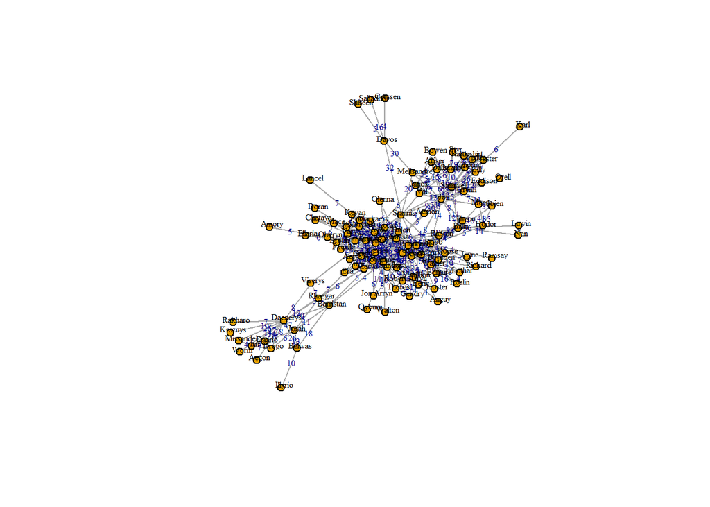

```r
g_game=graph_from_data_frame(data_game,directed = F)
plot(g_game,vertex.label.cex=0.5,#设置节点标签字号
     vertex.size=5,#设置节点大小
     vertex.label.dist=0.4,#设置节点的标签位置
     vertex.label.color="black",#修改节点标签的颜色
     edge.label=data_game$Weight,#标记边的权重
     edge.label.cex=0.5#边权的字号
     )
```

## 3、根据game of throne网络结构数据图得到邻接矩阵

```r
E(g_game)$weight<-data_game$Weight#提取每条边的权重
adj_game=as_adjacency_matrix(g_game,
                             attr="weight",#显示每条边的权值
                             sparse =FALSE#创建非稀疏矩阵
                             )
print(adj_game)
```

```
##              Aemon Aerys Alliser Amory Arya Balon Belwas Beric Bran Brienne
## Aemon            0     0       0     0    0     0      0     0    0       0
## Aerys            0     0       0     0    0     0      0     0    0       0
## Alliser          0     0       0     0    0     0      0     0    0       0
## Amory            0     0       0     0    0     0      0     0    0       0
## Arya             0     0       0     0    0     0      0    23    9       0
## Balon            0     0       0     0    0     0      0     0    0       0
## Belwas           0     0       0     0    0     0      0     0    0       0
## Beric            0     0       0     0   23     0      0     0    0       0
## Bran             0     0       0     0    9     0      0     0    0       0
## Brienne          0     0       0     0    0     0      0     0    0       0
## Bronn            0     0       0     0    0     0      0     0    0       0
## Brynden          0     0       0     0    6     0      0     0    0       0
## Catelyn          0     0       0     0    0     0      0     0    4       7
## Cersei           0     0       0     0    5     0      0     0    0       5
## Craster          0     0       0     0    0     0      0     0    0       0
## Daario           0     0       0     0    0     0      0     0    0       0
## Daenerys         0     0       0     0    0     0     26     0    0       0
## Davos            0     0       0     0    0     0      0     0    0       0
## Eddard           0     0       0     0   18     0      0     8   15       0
## Eddison          0     0       0     0    0     0      0     0    0       0
## Edmure           0     0       0     0    0     0      0     0    0       0
## Gendry           0     0       0     0   43     0      0     4    0       0
## Gilly            0     0       0     0    0     0      0     0    0       0
## Gregor           0     0       0     0    7     0      0     0    0       0
## Hodor            0     0       0     0    0     0      0     0   96       0
## Hoster           0     0       0     0    0     0      0     0    0       0
## Irri             0     0       0     0    0     0      0     0    0       0
## Jaime            0    18       0     0   11     6      0     0    0      88
## Janos            0     0       9     0    0     0      0     0    0       0
## Joffrey          0     0       0     0    6     0      0     0    0       0
## Jojen            0     0       0     0    0     0      0     0   46       0
## Jon             30     0      15     0    7     0      0     0   12       0
## Jon Arryn        0     0       0     0    0     0      0     0    0       0
## Jorah            0     0       0     0    0     0     13     0    0       0
## Kevan            0     0       0     0    0     0      0     0    0       0
## Loras            0     0       0     0    0     4      0     0    0       7
## Lothar           0     0       0     0    0     0      0     0    0       0
## Luwin            0     0       0     0    0     0      0     0    4       0
## Lysa             0     0       0     0    0     0      0     0    0       0
```

[output cut: 1241 more lines]

```
## Qyburn             0    0      0       0     0
## Bowen              0    0      0       0     0
## Margaery           0    0      0       0     0
## Dalla              0    0      0       0     0
## Orell              0    0      0       0     0
## Qhorin             0    0      0       0     0
## Styr               0    0      0       0     0
## Lancel             0    0      0       0     0
## Olenna             0    0      0       0     0
## Marillion          0    0      0       0     0
## Ellaria            0    0      0       0     0
## Mace               0    0      0       0     0
## Ramsay             0    0      0       0     0
## Chataya            0    0      0       0     0
## Doran              0    0      0       0     0
```

## 4、对得到的邻接矩阵进行矩阵分析

### （1）统计每个人物出现在对话中的累计次数

```r
dim(adj_game)#计算矩阵的行数和列数
```

```
## [1] 107 107
```

```r
edge_person=colSums(adj_game)#计算每个节点（人物）有多少条边（在两个人物对话中同时出现的次数)
edge_person
```

```
##        Aemon        Aerys      Alliser        Amory         Arya        Balon
##           74           37           29            5          269           29
##       Belwas        Beric         Bran      Brienne        Bronn      Brynden
##           67           75          344          122           59           55
##      Catelyn       Cersei      Craster       Daario     Daenerys        Davos
##          184          226           75           30          232           87
##       Eddard      Eddison       Edmure       Gendry        Gilly       Gregor
##          108           24           98           59           69          117
##        Hodor       Hoster         Irri        Jaime        Janos      Joffrey
##          177           24           33          372           37          255
##        Jojen          Jon    Jon Arryn        Jorah        Kevan        Loras
##          125          442           11           89           50           76
##       Lothar        Luwin         Lysa        Mance        Meera   Melisandre
##           34            8          108          160          139           62
##        Meryn    Missandei     Myrcella       Oberyn      Podrick  Rattleshirt
##           47           30           18           76           64           44
##        Renly      Rhaegar      Rickard       Rickon         Robb       Robert
##           55           42           11           81          342          128
## Robert Arryn        Roose      Samwell       Sandor        Sansa         Shae
##           19           17          282          137          383           45
##      Shireen      Stannis       Tommen       Tyrion        Tywin          Val
##            5          146           31          551          204           31
##        Varys      Viserys       Walder       Walton      Ygritte        Grenn
##           49           19           87           10           82           81
##        Anguy       Thoros    Barristan      Illyrio          Nan        Theon
##           15           60           63           10           18           38
##        Jeyne        Petyr       Roslin         Elia         Ilyn      Pycelle
##           28           89           32           29           32           24
##         Karl        Drogo        Aegon      Kraznys      Rakharo         Worm
##            6           35            8           10            7           14
##      Cressen    Salladhor       Qyburn        Bowen     Margaery        Dalla
##            4           16           11           11           96           21
##        Orell       Qhorin         Styr       Lancel       Olenna    Marillion
##            6           59           23            7           12           23
##      Ellaria         Mace       Ramsay      Chataya        Doran
##           10           20            4            9            5
```

### （2）计算每个人物平均被提及的次数

```r
mean_game=sum(edge_person)/dim(adj_game)[1]
print(mean_game)
```

```
## [1] 80.82243
```

```r
which(edge_person<mean_game)#统计有多少人物的被提及次数小于平均值
```

```
##        Aemon        Aerys      Alliser        Amory        Balon       Belwas
##            1            2            3            4            6            7
##        Beric        Bronn      Brynden      Craster       Daario      Eddison
##            8           11           12           15           16           20
##       Gendry        Gilly       Hoster         Irri        Janos    Jon Arryn
##           22           23           26           27           29           33
##        Kevan        Loras       Lothar        Luwin   Melisandre        Meryn
##           35           36           37           38           42           43
##    Missandei     Myrcella       Oberyn      Podrick  Rattleshirt        Renly
##           44           45           46           47           48           49
##      Rhaegar      Rickard Robert Arryn        Roose         Shae      Shireen
##           50           51           55           56           60           61
##       Tommen          Val        Varys      Viserys       Walton        Anguy
##           63           66           67           68           70           73
##       Thoros    Barristan      Illyrio          Nan        Theon        Jeyne
##           74           75           76           77           78           79
##       Roslin         Elia         Ilyn      Pycelle         Karl        Drogo
##           81           82           83           84           85           86
##        Aegon      Kraznys      Rakharo         Worm      Cressen    Salladhor
##           87           88           89           90           91           92
##       Qyburn        Bowen        Dalla        Orell       Qhorin         Styr
##           93           94           96           97           98           99
##       Lancel       Olenna    Marillion      Ellaria         Mace       Ramsay
##          100          101          102          103          104          105
##      Chataya        Doran
##          106          107
```

### （3）统计被提及次数最多和最少的人物

```r
max(edge_person)#计算一个节点权重的累计值
```

```
## [1] 551
```

```r
which(edge_person==max(edge_person))#找出边数连接最多的节点
```

```
## Tyrion
##     64
```

```r
min(edge_person)#计算一个节点最少连接的边数
```

```
## [1] 4
```

```r
which(edge_person==min(edge_person))#找出边数连接最少的节点
```

```
## Cressen  Ramsay
##      91     105
```

#### 通过对领接矩阵的分析可知，从总体上看，电影中人物在对话中的出现频率平均约为了81次，且在107个节点中有74个节点边的连接数（被提及次数）小于平均值。再细化到各个人物，可以发现，在权游的人物对话当中Tyrion出现的次数最多，频数总计是551次，可见Tyrion在电影中很可能是主角或者比较重要的角色担当，而在对话中被提及次数最少,仅有4次的是Cressen,Ramsay，占总的人物提及次数的比重较小，可以推测这两角色的戏份相对较少。